# Exam Practice

Syed Naqvi - 100590852

19 April, 2024

## Loading Relevant Libraries

```r
graphics.off()
rm(list = ls())
library(tidyverse)
library(ggthemes)
```

## Part 1 - Scatter Plot and Regression

### 1.

- we can create a scatter plot that compares the engine fuel displacement and highway mileage, colored by number of cylinders

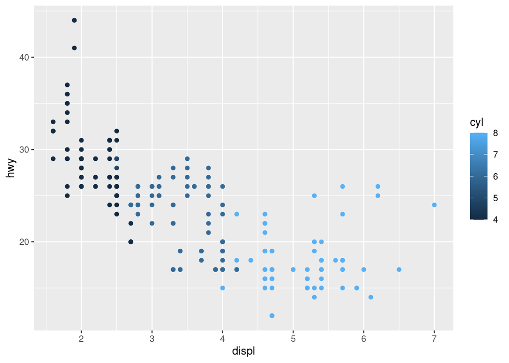

```r
mpg |>
  ggplot(aes(x = displ, y = hwy, colour = cyl)) +
  geom_point()
```

### 2.

- The cylinders aesthetic is currently mapped to a continuous scale but we need to create a discrete colour mapping
- we can first mutate the cylinder variable to a factor which will treat the values as categorical as opposed to continuous

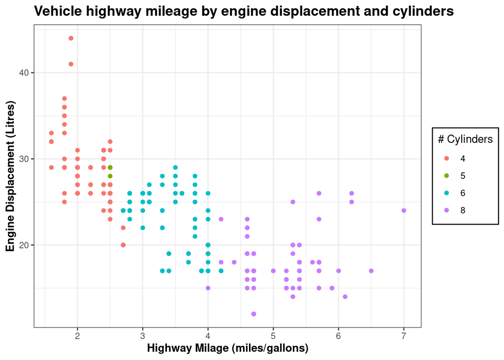

```r
mpg |>
  mutate(cyl = factor(cyl)) |>
  ggplot(aes(x = displ, y = hwy, colour = cyl)) +
  geom_point() +
  labs(title = "Vehicle highway mileage by engine displacement and cylinders",
       x = "Highway Milage (miles/gallons)",
       y = "Engine Displacement (Litres)",
       colour = "# Cylinders") +
  theme_bw() +
  theme(plot.title = element_text(size = 14, face = "bold"),
        axis.title = element_text(face = "bold"),
        legend.background = element_rect(colour = "black"))
```

### 3. 4. 5.

- we can overlay linear regression fits to our graph with separate fits for each cylinder

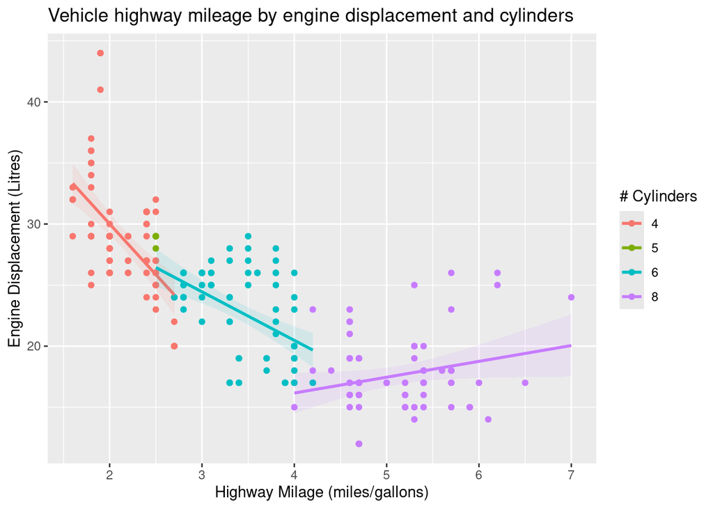

```r
mpg |>
  mutate(cyl = factor(cyl)) |>
  ggplot(aes(x = displ, y = hwy, colour = cyl, fill = cyl)) +
  geom_point() +
  geom_smooth(method = "lm", alpha = 0.1) +
  labs(title = "Vehicle highway mileage by engine displacement and cylinders",
       x = "Highway Milage (miles/gallons)",
       y = "Engine Displacement (Litres)",
       colour = "# Cylinders") +
  guides(fill = "none")
```

## Part 2 - Playing with colour

### 6.

- Hue is the actual colour like blue, red, green, yellow, purple, etc…
- Chroma is the intensity of the colour so very high chroma for the hue of blue would be intense and rich blue while low chroma
  - for the colour of blue would essentially be grey
- Luminance is the brightness, so high luminance is just white while low luminance is black

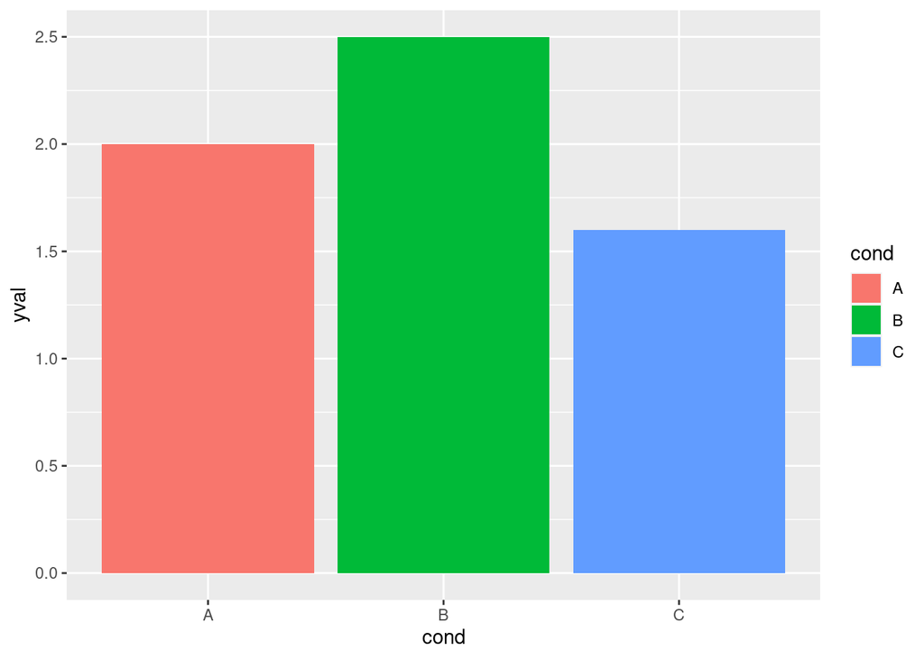

```r
load("./Final Worksheet/W6-8.RData")

ggplot(d_p2, aes(x = cond, y = yval, fill = cond)) +
  geom_col()
```

### 9.

- Hue is the actual colour like blue, red, green, yellow, purple, etc…
- Chroma is the intensity of the colour so very high chroma for the hue of blue would be intense and rich blue while low chroma
  - for the colour of blue would essentially be grey
- Luminance is the brightness, so high luminance is just white while low luminance is black

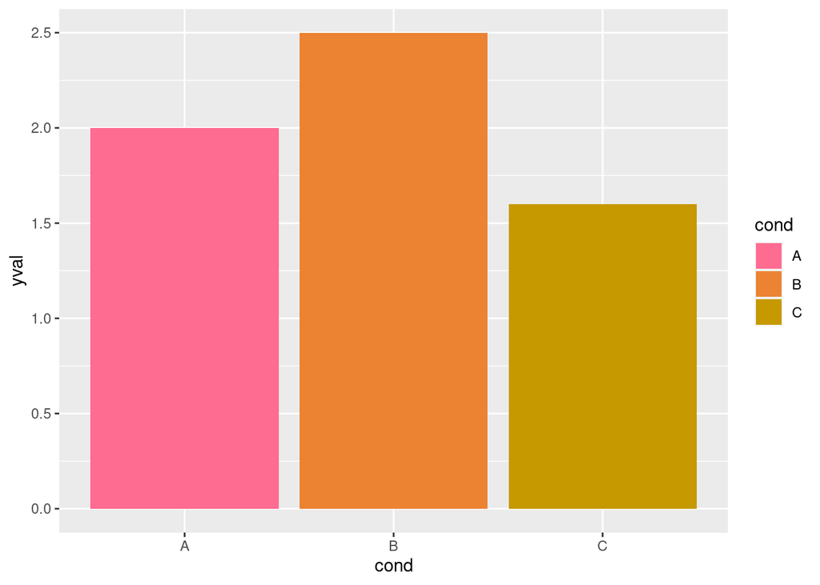

```r
ggplot(d_p2, aes(x = cond, y = yval, fill = cond)) +
  geom_col() +
  scale_fill_hue(h.start = 0, h = c(0, 65))
```

## Part 3 - Proportional Data

### 11.

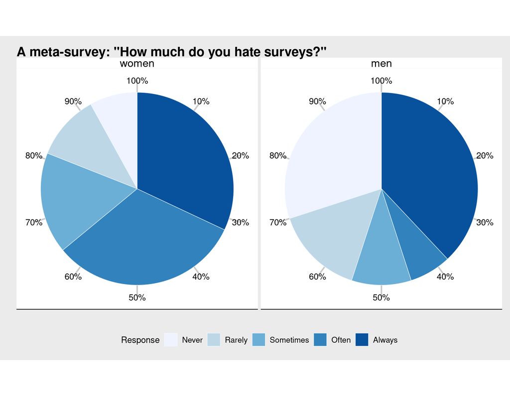

```r
d_p3 <- d_p3 |>
  mutate(Response = factor(Response,
                           levels = c(1,2,3,4,5),
                           labels = c("Never", "Rarely", "Sometimes", "Often", "Always")),
         Gender = factor(Gender,
                         levels = c(1,2),
                         labels = c("women", "men")))
p <- d_p3 |>
  ggplot(aes(x = "", y = Summary, fill = Response)) +
  geom_col(colour = "aliceblue", linewidth = 0.25) +
  coord_polar(theta = "y") +
  facet_wrap(~Gender) +
  scale_y_continuous(breaks = seq(from = 0.1, to = 1, by = 0.1),
                     labels = scales::label_percent(scale = 100, suffix = "%")) +
  scale_fill_brewer(palette = "Blues") +
  labs(title = "A meta-survey: \"How much do you hate surveys?\"",
       x = NULL, y = NULL) +
  guides(fill = guide_legend(Reverse = TRUE)) +
  theme_economist_white()+
  theme(legend.direction = "horizontal",
        legend.position = "bottom",
        legend.text = element_text(size = 10))

p
```